# Week 2 lab session practice

# General instructions

During this lab session, you will write R code to answer questions on data analysis topics you have seen in the main lectures and the demonstration videos. By completing the tasks in this document, **you will practice**:

- inferential testing,
- basic Exploratory data analysis (EDA) techniques,
- missing data descriptives,
- univariate outlier analysis,
- multivariate outlier analysis

To answer the questions in this practice sheet:

1. Download the ZIP archive `week-2-lab.zip`, which you can find on the course Canvas page under [Week 2 > Lab](https://tilburguniversity.instructure.com/courses/12505/modules#module_99399).
2. Unzip the archive.
3. Open `week-2-practice.R` located in the `code/` sub-folder and set the **working directory** to its location. In RStudio,

   ```
   Session > Set Working Directory > To Source File Location
   ```

4. Apply the code you saw in the demonstration scripts and pre-recorded demonstration videos to answer the questions below.

**Tip**: *Use code comments* (introduced by `#` in an R script) to keep track of which questions your code is answering to (follow the example shown in `week-2-practice.R`.)

You will need four **datasets**:

- `bfi_clean.rds`
- `tests.rds`
- `bfiOE.rds`
- `airQual.rds`

These datasets are stored in the `data/` sub-folder of the `week-2-lab` folder.

# 1 Preliminaries

## 1.1 - If you have not already done so, use the `install.packages` function to install the `mice` package.

```r
# Install the mice R package if you don't have it yet
install.packages("mice")
```

## 1.2 - Use the `library` function to load the `mice` and `MASS` packages.

```r
# Load packages
library(mice)
library(MASS)
```

## 1.3 - Use the `paste0` function and the `readRDS` function to load the four datasets into memory.

```r
# Define the path to the data directory
dataDir <- "../data/"

# Read the different data sets we will need for this session
bfi1 <- readRDS(paste0(dataDir, "bfi_clean.rds"))
bfi2 <- readRDS(paste0(dataDir, "bfiOE.rds"))
tests <- readRDS(paste0(dataDir, "tests.rds"))
airQual <- readRDS(paste0(dataDir, "airQual.rds"))
```

# 2 Inferential testing

Use the `bfi_clean` data to answer the questions in this section.

## 2.1 - Conduct a t-test to check for sex differences in mean levels of `agree` (i.e., agreeableness), without assuming equal variances.

```r
# Perform t test
out1.1 <- t.test(agree ~ sex, data = bfi1)

# Print output
out1.1
```

```
    Welch Two Sample t-test

data:  agree by sex
t = -10.966, df = 1691.6, p-value < 2.2e-16
alternative hypothesis: true difference in means between group male and group female is not equal to 0
95 percent confidence interval:
 -0.4699645 -0.3273594
sample estimates:
  mean in group male mean in group female
            4.384113             4.782775
```

## 2.2 - What is the value of the estimated mean difference in `agree`?

```r
# Compute difference between groups
diff(out1.1$estimate)
```

```
mean in group female
            0.398662
```

```r
# Compute difference between groups in "reverse" order
diff(rev(out1.1$estimate))
```

```
mean in group male
         -0.398662
```

## 2.3 - What is the value of the estimated t-statistic?

```r
# Extract the value of the test statistic from the t-test R object
out1.1$statistic
```

```
        t
-10.96626
```

## 2.4 - Is the estimated mean difference significant at the alpha = 0.05 level?

```r
# Check whether the p-values is smaller than the alpha level with an ifelse
ifelse(out1.1$p.value < 0.05, "YES", "NO")
```

```
[1] "YES"
```

# 3 Basic EDA techniques

Use the `tests` data to answer the questions in this section.

## 3.1 - What are the dimensions of these data?

```r
# Print the number of rows and columns of a data table
dim(tests)
```

```
[1] 700   6
```

## 3.2 - What is the mean `SATQ` score?

```r
# Compute the mean of the SATQ column
mean(tests$SATQ)
```

```
[1] 609.6414
```

## 3.3 - What is the variance of the `SATQ` scores?

```r
# Compute the variance of the SATQ column
var(tests$SATQ)
```

```
[1] 13357.14
```

## 3.4 - What is the median `SATV` score?

```r
# Compute the MEDIAN of the SATV column
median(tests$SATV)
```

```
[1] 620
```

## 3.5 - Create a histogram of the `ACT` variable.

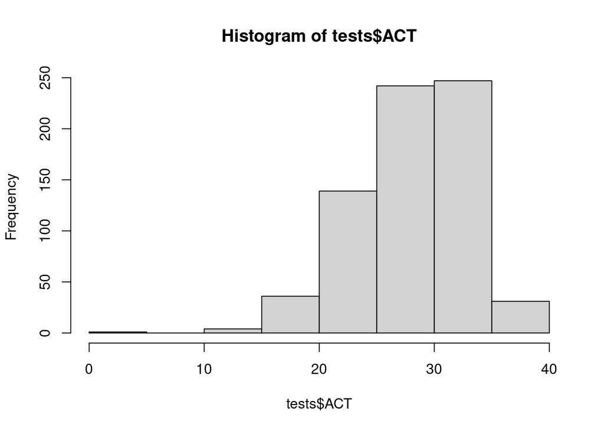

```r
# Create a histogram of the "ACT" variable.
hist(tests$ACT)
```

## 3.6 - Create a kernel density plot of the `ACT` variable.

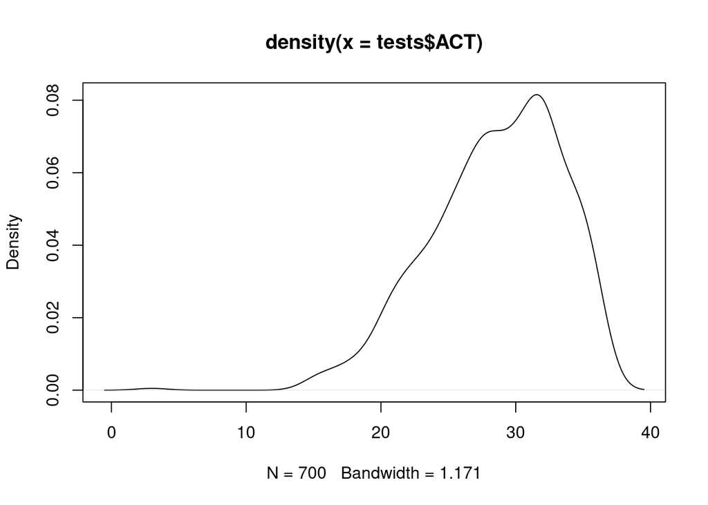

```r
# Create a kernel density plot of the "ACT" variable.
plot(density(tests$ACT))
```

## 3.7 - Overlay a normal density on top of the `ACT` histogram.

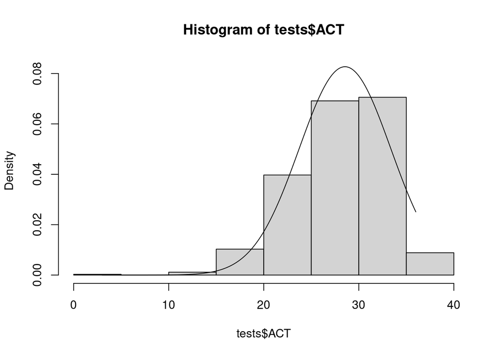

```r
# Compute the mean of ACT
m <- mean(tests$ACT)

# Compute the standard deviation of ACT
s <- sd(tests$ACT)

# create a sequence of value between the max and min of ACT
x <- with(tests, seq(min(ACT), max(ACT), length.out = 1000))

# Compute the pdf values for the variable x
d <- dnorm(x = x, mean = m, sd = s)

# Plot the histogram of ACT on a probability scale
hist(tests$ACT, probability = TRUE, ylim = range(d))

# Add the density line
lines(x = x, y = d)
```

## 3.8 - Create a grouped boxplot that plots `ACT` by `education`.

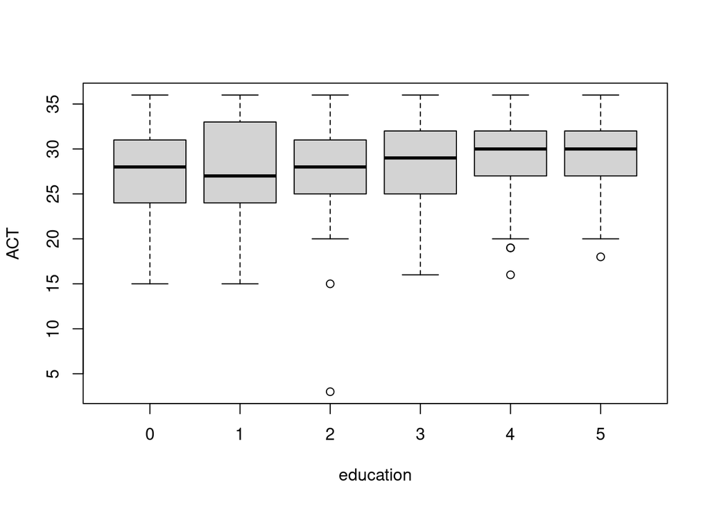

```r
# Group data with the with() function and use the boxplot function
with(tests, boxplot(ACT ~ education))
```

## 3.9 - Create a frequency table of `education`.

You can always use the `table()` function to create frequency tables.

```r
# Create a frequency table of "education".
table(tests$education)
```

```
  0   1   2   3   4   5
 57  45  44 275 138 141
```

## 3.10 - Create a contingency table that cross-classifies `sex` and `education`.

You can always use the `table()` function to create contingency tables (i.e., multivariate frequency tables.)

```r
# Use the table function to create contingency tables
table(tests$sex, tests$education)
```

```
           0   1   2   3   4   5
  male    27  20  23  80  51  46
  female  30  25  21 195  87  95
```

```r
# Combine it with the with() funciton for tidier code
with(tests, table(sex, education))
```

```
        education
sex        0   1   2   3   4   5
  male    27  20  23  80  51  46
  female  30  25  21 195  87  95
```

## 3.11 - Suppose a certain university admits any student with an ACT score of, at least, 25. How many of the women in the `tests` data would be admitted?

```r
# Create a contingency table for sex and those with a score higher or equal
# to 25
tab <- with(tests, table(sex, admit = ACT >= 25))

# Print it
tab
```

```
        admit
sex      FALSE TRUE
  male      46  201
  female    94  359
```

```r
# And print only the cell that answers the question
tab["female", "TRUE"]
```

```
[1] 359
```

```r
# Alternatively, just sum how many times the conditions are met
sum(with(tests, sex == "female" & ACT >= 25))
```

```
[1] 359
```

# 4 Missing data descriptives

Use the `bfiOE` data to answer the questions in this section.

## 4.1 - Compute the proportion of missing values for each variable.

```r
# Compute the proportion of times a value is missing per column
pm <- colMeans(is.na(bfi2))

# Print the resulting vector
pm
```

```
        E1         E2         E3         E4         E5         O1         O2         O3         O4         O5        sex  education        age
0.04078014 0.02836879 0.04432624 0.01595745 0.03723404 0.03900709 0.00000000 0.04964539 0.02482270 0.03546099 0.00000000 0.39539007 0.00000000
```

## 4.2 - What is the percentage of missing data for `O1`?

```r
# Extract the value corresponding to the desired variable and multiply by 100
pm["O1"] * 100
```

```
      O1
3.900709
```

## 4.3 - Compute the number of observed values for each variable:

```r
# Sum the number of times that a value is observed per column
nObs <- colSums(!is.na(bfi2))

# Print the resulting vector
nObs
```

```
       E1        E2        E3        E4        E5        O1        O2        O3        O4        O5       sex education       age
      541       548       539       555       543       542       564       536       550       544       564       341       564
```

## 4.4 - What is the number of observed values for `E1`?

```r
# Extract the value of interest from the vector just computed
nObs["E1"]
```

```
 E1
541
```

## 4.5 - Compute the covariance coverage matrix.

Use the `md.pairs()` function to extract the number of rows which respond two pairs of variables and divide by total number of cases.

```r
# Compute the covariance coverage matrix.
cc <- md.pairs(bfi2)$rr / nrow(bfi2)

# Print the resulting matrix
cc
```

```
                 E1        E2        E3        E4        E5        O1        O2        O3        O4        O5       sex education       age
E1        0.9592199 0.9308511 0.9219858 0.9432624 0.9273050 0.9273050 0.9592199 0.9184397 0.9343972 0.9308511 0.9592199 0.5691489 0.9592199
E2        0.9308511 0.9716312 0.9273050 0.9556738 0.9343972 0.9343972 0.9716312 0.9219858 0.9468085 0.9379433 0.9716312 0.5762411 0.9716312
E3        0.9219858 0.9273050 0.9556738 0.9397163 0.9237589 0.9237589 0.9556738 0.9202128 0.9308511 0.9308511 0.9556738 0.5691489 0.9556738
E4        0.9432624 0.9556738 0.9397163 0.9840426 0.9468085 0.9450355 0.9840426 0.9361702 0.9592199 0.9485816 0.9840426 0.5921986 0.9840426
E5        0.9273050 0.9343972 0.9237589 0.9468085 0.9627660 0.9290780 0.9627660 0.9184397 0.9379433 0.9326241 0.9627660 0.5709220 0.9627660
O1        0.9273050 0.9343972 0.9237589 0.9450355 0.9290780 0.9609929 0.9609929 0.9184397 0.9361702 0.9326241 0.9609929 0.5691489 0.9609929
O2        0.9592199 0.9716312 0.9556738 0.9840426 0.9627660 0.9609929 1.0000000 0.9503546 0.9751773 0.9645390 1.0000000 0.6046099 1.0000000
O3        0.9184397 0.9219858 0.9202128 0.9361702 0.9184397 0.9184397 0.9503546 0.9503546 0.9255319 0.9255319 0.9503546 0.5656028 0.9503546
O4        0.9343972 0.9468085 0.9308511 0.9592199 0.9379433 0.9361702 0.9751773 0.9255319 0.9751773 0.9397163 0.9751773 0.5815603 0.9751773
O5        0.9308511 0.9379433 0.9308511 0.9485816 0.9326241 0.9326241 0.9645390 0.9255319 0.9397163 0.9645390 0.9645390 0.5762411 0.9645390
sex       0.9592199 0.9716312 0.9556738 0.9840426 0.9627660 0.9609929 1.0000000 0.9503546 0.9751773 0.9645390 1.0000000 0.6046099 1.0000000
education 0.5691489 0.5762411 0.5691489 0.5921986 0.5709220 0.5691489 0.6046099 0.5656028 0.5815603 0.5762411 0.6046099 0.6046099 0.6046099
age       0.9592199 0.9716312 0.9556738 0.9840426 0.9627660 0.9609929 1.0000000 0.9503546 0.9751773 0.9645390 1.0000000 0.6046099 1.0000000
```

## 4.6 - What is the range of covariance coverage values?

```r
# Extract unique coverage values:
cc2 <- cc[lower.tri(cc)]

# Compute the range (i.e., min / max values)
range(cc2)
```

```
[1] 0.5656028 1.0000000
```

Note that the diagonal of the covariance coverage matrix contains the proportion of observed cases for each variable. So we generally don’t include its elements when thinking of the covariance coverage values. If you wanted to, you could obtain the unique coverage value including the diagonal with:

```r
# Include diagonal elements
cc[lower.tri(cc, diag = TRUE)]
```

## 4.7 - What is the covariance coverage between `E2` and `O4`?

```r
# What is the covariance coverage between "E2" and "O4"?
cc["E2", "O4"]
```

```
[1] 0.9468085
```

## 4.8 - How many unique covariance coverages are less than 0.75?

```r
# Sum the number of unique covariance coverages that are less than 0.75
sum(cc2 < 0.75)
```

```
[1] 12
```

## 4.9 - Compute the missing data patterns for these data.

```r
# Compute the missing data patterns for these data.
pats <- md.pattern(bfi2, plot = FALSE)

# Print the missing data matrix
pats
```

```
    O2 sex age E4 O4 E2 O5 E5 O1 E1 E3 O3 education
205  1   1   1  1  1  1  1  1  1  1  1  1         1   0
210  1   1   1  1  1  1  1  1  1  1  1  1         0   1
16   1   1   1  1  1  1  1  1  1  1  1  0         1   1
2    1   1   1  1  1  1  1  1  1  1  1  0         0   2
16   1   1   1  1  1  1  1  1  1  1  0  1         1   1
1    1   1   1  1  1  1  1  1  1  1  0  1         0   2
1    1   1   1  1  1  1  1  1  1  1  0  0         1   2
1    1   1   1  1  1  1  1  1  1  1  0  0         0   3
17   1   1   1  1  1  1  1  1  1  0  1  1         1   1
1    1   1   1  1  1  1  1  1  1  0  1  1         0   2
1    1   1   1  1  1  1  1  1  1  0  1  0         1   2
17   1   1   1  1  1  1  1  1  0  1  1  1         1   1
17   1   1   1  1  1  1  1  0  1  1  1  1         1   1
1    1   1   1  1  1  1  1  0  1  1  1  1         0   2
```

[output cut: 16 more lines]

## 4.10 - How many distinct missing data patterns exist in these data?

The missing data matrix obtained with `md.pattern()` returns a matrix with rows describing the unique missing data patterns. Therefore, you can answer this question by simply counting the number of rows in the matrix. Although, remember that the last row of the matrix is a summary, not a missing data pattern.

```r
# How many distinct missing data patterns exist in these data?
nrow(pats) - 1
```

```
[1] 29
```

## 4.11 - How many missing data patterns have only one missing value?

The last column of the missing data pattern matrix contains the counts of how many variables are unobserved for a given missing data pattern. Check how many of these values are equal to 1.

```r
# Find the entries in the last column equal to 1:
flag <- pats[-nrow(pats), ncol(pats)] == 1

# Sum how many times the condition is met
sum(flag)
```

```
[1] 10
```

## 4.12 - How many observations are affected by patterns that involve only one missing value?

The rownames of the missing data pattern matrix contain the information on how many observations are affected by each missing data pattern. These values are stored as characters, so we need to convert them to a numeric vector and then sum the numbers meeting the condition described by the question (which is the same as described in question 4.11). Remember that the final row(name) has a different meaning.

```r
# Convert the row names of the pats matrix to numbers
counts <- as.numeric(rownames(pats))[-nrow(pats)]

# Use the flag vector you created before to keep only the values of interest
counts[flag]
```

```
 [1] 210  16  16  17  17  17  12  14  13   6
```

```r
# And sum them to obtain the solution
sum(counts[flag])
```

```
[1] 338
```

# 5 Univariate outliers

In answering the following questions, you should:

- use the `airQual` data to answer the questions in this section;
- use the functions provided in the demonstration scripts.

## 5.1 - Use Tukey’s boxplot method to find possible and probable outliers in the `Ozone`, `Solar.R`, `Wind`, and `Temp` variables.

First, make sure you have the `bpOutliers()` function in your environment. If you don’t, run the code defining the function from the lab demonstration script.

```r
# Function to implement the boxplot method:
bpOutliers <- function(x) {
     # Compute inner and outer fences:
     iFen <- boxplot.stats(x, coef = 1.5)$stats[c(1, 5)]
     oFen <- boxplot.stats(x, coef = 3.0)$stats[c(1, 5)]

     # Return the row indices of flagged 'possible' and 'probable' outliers:
     list(
          possible = which(x < iFen[1] | x > iFen[2]),
          probable = which(x < oFen[1] | x > oFen[2])
     )
}
```

Then, you can use the `bpOutliers()` function to answer the question.

```r
# Define a vector of variable names:
vars <- c("Ozone", "Solar.R", "Wind", "Temp")

# Apply the bpOutliers() to the columns of airQual corresponding to these names:
bpOuts <- lapply(airQual[vars], bpOutliers)

# And look at the results
bpOuts
```

```
$Ozone
$Ozone$possible
[1]  39  43  62  99 102 117

$Ozone$probable
integer(0)


$Solar.R
$Solar.R$possible
integer(0)

$Solar.R$probable
integer(0)


$Wind
$Wind$possible
[1]  9 18 48

$Wind$probable
integer(0)


$Temp
$Temp$possible
integer(0)

$Temp$probable
integer(0)
```

## 5.2 - Did you find any possible outliers?

```r
# Extract possible outliers:
posOl <- lapply(bpOuts, "[[", x = "possible")

# Check for the presence of possible outliers:
check <- any(sapply(posOl, length) > 0)
ifelse(check, "YES", "NO")
```

```
[1] "YES"
```

## 5.3 - Did you find any probable outliers?

```r
# Extract probable outliers:
probOl <- lapply(bpOuts, "[[", x = "probable")

# Check for the presence of probable outliers:
check <- any(sapply(probOl, length) > 0)
ifelse(check, "YES", "NO")
```

```
[1] "NO"
```

## 5.4 - Which, if any, observations were possible outliers on `Ozone`?

```r
# Extract the Ozone possible outliers
bpOuts$Ozone$possible
```

```
[1]  39  43  62  99 102 117
```

## 5.5 - Which, if any, observations were probable outliers on `Wind`?

```r
# Extract the Wind probable outliers
bpOuts$Wind$probable
```

```
integer(0)
```

## 5.6 - Use the MAD method (with a cutoff of 3) to find potential outliers in the `Ozone`, `Solar.R`, `Wind`, and `Temp` variables.

```r
# Make sure the function to implement the MAD method is in your environment:
madOutliers <- function(x, cut = 2.5, na.rm = TRUE) {
     # Compute the median and MAD of x:
     mX <- median(x, na.rm = na.rm)
     madX <- mad(x, na.rm = na.rm)

     # Return row indices of observations for which |T_MAD| > cut:
     which(abs(x - mX) / madX > cut)
}

# Apply the function to all of the variables of interest
madOuts <- lapply(airQual[vars], madOutliers, cut = 3.0)

# Print the resulting vector
madOuts
```

```
$Ozone
 [1]  30  39  43  62  86  99 101 102 117 121

$Solar.R
integer(0)

$Wind
[1]  9 48

$Temp
integer(0)
```

## 5.7 - Did you find any potential outliers?

```r
# Check for potential outliers according to MAD
check <- length(unlist(madOuts)) > 0
ifelse(check, "YES", "NO")
```

```
[1] "YES"
```

## 5.8 - Which, if any, observations are potential outliers on `Wind`?

```r
# Check the potential outliers on Wind
madOuts$Wind
```

```
[1]  9 48
```

# 6 Multivariate outliers

In answering the following questions, you should:

- use the `airQual` data;
- use the **robust** MCD Mahalanobis distance to check for multivariate outliers on the `Ozone`, `Solar.R`, `Wind`, and `Temp` variables;
- use the functions provided in the demonstrations script to complete the following tasks;
- set the seed to `235711`, when running the `mcdMahalanobis()` function.

## 6.1 - Which, if any, observations are flagged as multivariate outliers when using 75% of the sample for the MCD estimation and using a probability of 0.99 for the cutoff value?

```r
# Make sure the function to implement the robust Mahalanobis distance is in your environment:
mcdMahalanobis <- function(data, prob, ratio = 0.75, seed = NULL) {
     # Set a seed, if one is provided:
     if (!is.null(seed)) set.seed(seed)

     # Compute the MCD estimates of the mean and covariance matrix:
     stats <- cov.mcd(data, quantile.used = floor(ratio * nrow(data)))

     # Compute robust squared Mahalanobis distances
     md <- mahalanobis(x = data, center = stats$center, cov = stats$cov)

     # Find the cutoff value:
     crit <- qchisq(prob, df = ncol(data))

     # Return row indices of flagged observations:
     which(md > crit)
}

# MCD Mahalanobis outliers 0.99 and 0.75
mcdMahalanobis(airQual[vars], prob = 0.99, ratio = 0.75, seed = 235711)
```

```
 [1]   5   8   9  15  18  24  25  26  30  39  43  48  62  75 102 117 148
```

## 6.2 - Which, if any, observations are flagged as multivariate outliers when using 75% of the sample for the MCD estimation and using a probability of 0.999 for the cutoff value?

```r
# MCD Mahalanobis outliers 0.999 and 0.75
mcdMahalanobis(airQual[vars], prob = 0.999, ratio = 0.75, seed = 235711)
```

```
 [1]   9  18  26  30  39  43  48  62 102 117
```

## 6.3 - Which, if any, observations are flagged as multivariate outliers when using 50% of the sample for the MCD estimation and using a probability of 0.99 for the cutoff value?

```r
# MCD Mahalanobis outliers 0.99 and 0.5
mcdMahalanobis(airQual[vars], prob = 0.99, ratio = 0.5, seed = 235711)
```

```
 [1]   5   8   9  15  18  21  23  24  25  26  27  30  34  39  43  48  62  75  86 102 117 148
```

## 6.4 - Which, if any, observations are flagged as multivariate outliers when using 50% of the sample for the MCD Which and using a probability of 0.999 for the cutoff value?

```r
# MCD Mahalanobis outliers 0.999 and 0.5
mcdMahalanobis(airQual[vars], prob = 0.999, ratio = 0.5, seed = 235711)
```

```
 [1]   5   8   9  15  18  24  25  26  27  30  39  43  48  62  75 102 117 148
```

## 6.5 - Based on the above, what consequences do you observe when changing the fraction of the sample used for MCD estimation and when changing the cutoff probability?

Increasing the cutoff probability or the sample ratio decreases the number of identified outliers.

# 7 TL;DR, just give me the code!

You can paste the following code in your `week-2-practice.R` and run it to obtain the solutions shown here.

```r
# Install the mice R package if you don't have it yet
install.packages("mice")
# Load packages
library(mice)
library(MASS)
# Define the path to the data directory
dataDir <- "../data/"

# Read the different data sets we will need for this session
bfi1 <- readRDS(paste0(dataDir, "bfi_clean.rds"))
bfi2 <- readRDS(paste0(dataDir, "bfiOE.rds"))
tests <- readRDS(paste0(dataDir, "tests.rds"))
airQual <- readRDS(paste0(dataDir, "airQual.rds"))
# Perform t test
out1.1 <- t.test(agree ~ sex, data = bfi1)

# Print output
out1.1
# Compute difference between groups
diff(out1.1$estimate)

# Compute difference between groups in "reverse" order
diff(rev(out1.1$estimate))
# Extract the value of the test statistic from the t-test R object
out1.1$statistic
# Check whether the p-values is smaller than the alpha level with an ifelse
ifelse(out1.1$p.value < 0.05, "YES", "NO")
# Print the number of rows and columns of a data table
dim(tests)
# Compute the mean of the SATQ column
mean(tests$SATQ)
# Compute the variance of the SATQ column
var(tests$SATQ)
# Compute the MEDIAN of the SATV column
median(tests$SATV)
# Create a histogram of the "ACT" variable.
hist(tests$ACT)
# Create a kernel density plot of the "ACT" variable.
plot(density(tests$ACT))
# Compute the mean of ACT
m <- mean(tests$ACT)

# Compute the standard deviation of ACT
s <- sd(tests$ACT)

# create a sequence of value between the max and min of ACT
x <- with(tests, seq(min(ACT), max(ACT), length.out = 1000))

# Compute the pdf values for the variable x
d <- dnorm(x = x, mean = m, sd = s)

# Plot the histogram of ACT on a probability scale
hist(tests$ACT, probability = TRUE, ylim = range(d))

# Add the density line
lines(x = x, y = d)
# Group data with the with() function and use the boxplot function
with(tests, boxplot(ACT ~ education))
cat("You can always use the `table()` function to create frequency tables.")
# Create a frequency table of "education".
table(tests$education)
cat(
     "You can always use the `table()` function to create contingency tables
     (i.e., multivariate frequency tables.)"
)
# Use the table function to create contingency tables
table(tests$sex, tests$education)

# Combine it with the with() funciton for tidier code
with(tests, table(sex, education))
# Create a contingency table for sex and those with a score higher or equal
# to 25
tab <- with(tests, table(sex, admit = ACT >= 25))

# Print it
tab

# And print only the cell that answers the question
tab["female", "TRUE"]

# Alternatively, just sum how many times the conditions are met
sum(with(tests, sex == "female" & ACT >= 25))
# Compute the proportion of times a value is missing per column
pm <- colMeans(is.na(bfi2))

# Print the resulting vector
pm
# Extract the value corresponding to the desired variable and multiply by 100
pm["O1"] * 100
# Sum the number of times that a value is observed per column
nObs <- colSums(!is.na(bfi2))

# Print the resulting vector
nObs
# Extract the value of interest from the vector just computed
nObs["E1"]
cat(
     "Use the `md.pairs()` function to extract the number of rows which respond
     two pairs of variables and divide by total number of cases."
)
# Compute the covariance coverage matrix.
cc <- md.pairs(bfi2)$rr / nrow(bfi2)

# Print the resulting matrix
cc
# Extract unique coverage values:
cc2 <- cc[lower.tri(cc)]

# Compute the range (i.e., min / max values)
range(cc2)
cat(
     "Note that the diagonal of the covariance coverage matrix contains the proportion of observed cases for each variable. So we generally don't include its elements when thinking of the covariance coverage values. If you wanted to, you could obtain the unique coverage value including the diagonal with:"
)
# Include diagonal elements
cc[lower.tri(cc, diag = TRUE)]
# What is the covariance coverage between "E2" and "O4"?
cc["E2", "O4"]
# Sum the number of unique covariance coverages that are less than 0.75
sum(cc2 < 0.75)
# Compute the missing data patterns for these data.
pats <- md.pattern(bfi2, plot = FALSE)

# Print the missing data matrix
pats
cat(
     "The missing data matrix obtained with `md.pattern()` returns a matrix with
     rows describing the unique missing data patterns. Therefore, you can answer
     this question by simply counting the number of rows in the matrix. Although,
     remember that the last row of the matrix is a summary, not a missing data
     pattern."
)
# How many distinct missing data patterns exist in these data?
nrow(pats) - 1
cat(
     "The last column of the missing data pattern matrix contains the counts of
     how many variables are unobserved for a given missing data pattern.
     Check how many of these values are equal to 1."
)
# Find the entries in the last column equal to 1:
flag <- pats[-nrow(pats), ncol(pats)] == 1

# Sum how many times the condition is met
sum(flag)
cat(
     "The rownames of the missing data pattern matrix contain the information on
     how many observations are affected by each missing data pattern.
     These values are stored as characters, so we need to convert them to a
     numeric vector and then sum the numbers meeting the condition described by
     the question (which is the same as described in question
     \\@ref(miss-pat-only-one)).
     Remember that the final row(name) has a different meaning."
)
# Convert the row names of the pats matrix to numbers
counts <- as.numeric(rownames(pats))[-nrow(pats)]

# Use the flag vector you created before to keep only the values of interest
counts[flag]

# And sum them to obtain the solution
sum(counts[flag])
cat(
     "First, make sure you have the `bpOutliers()` function in your environment.
     If you don't, run the code defining the function from the lab demonstration
     script."
)
# Function to implement the boxplot method:
bpOutliers <- function(x) {
     # Compute inner and outer fences:
     iFen <- boxplot.stats(x, coef = 1.5)$stats[c(1, 5)]
     oFen <- boxplot.stats(x, coef = 3.0)$stats[c(1, 5)]

     # Return the row indices of flagged 'possible' and 'probable' outliers:
     list(
          possible = which(x < iFen[1] | x > iFen[2]),
          probable = which(x < oFen[1] | x > oFen[2])
     )
}
cat(
     "Then, you can use the `bpOutliers()` function to answer the question."
)
# Define a vector of variable names:
vars <- c("Ozone", "Solar.R", "Wind", "Temp")

# Apply the bpOutliers() to the columns of airQual corresponding to these names:
bpOuts <- lapply(airQual[vars], bpOutliers)

# And look at the results
bpOuts
# Extract possible outliers:
posOl <- lapply(bpOuts, "[[", x = "possible")

# Check for the presence of possible outliers:
check <- any(sapply(posOl, length) > 0)
ifelse(check, "YES", "NO")
# Extract probable outliers:
probOl <- lapply(bpOuts, "[[", x = "probable")

# Check for the presence of probable outliers:
check <- any(sapply(probOl, length) > 0)
ifelse(check, "YES", "NO")
# Extract the Ozone possible outliers
bpOuts$Ozone$possible
# Extract the Wind probable outliers
bpOuts$Wind$probable
# Make sure the function to implement the MAD method is in your environment:
madOutliers <- function(x, cut = 2.5, na.rm = TRUE) {
     # Compute the median and MAD of x:
     mX <- median(x, na.rm = na.rm)
     madX <- mad(x, na.rm = na.rm)

     # Return row indices of observations for which |T_MAD| > cut:
     which(abs(x - mX) / madX > cut)
}

# Apply the function to all of the variables of interest
madOuts <- lapply(airQual[vars], madOutliers, cut = 3.0)

# Print the resulting vector
madOuts
# Check for potential outliers according to MAD
check <- length(unlist(madOuts)) > 0
ifelse(check, "YES", "NO")
# Check the potential outliers on Wind
madOuts$Wind
# Make sure the function to implement the robust Mahalanobis distance is in your environment:
mcdMahalanobis <- function(data, prob, ratio = 0.75, seed = NULL) {
     # Set a seed, if one is provided:
     if (!is.null(seed)) set.seed(seed)

     # Compute the MCD estimates of the mean and covariance matrix:
     stats <- cov.mcd(data, quantile.used = floor(ratio * nrow(data)))

     # Compute robust squared Mahalanobis distances
     md <- mahalanobis(x = data, center = stats$center, cov = stats$cov)

     # Find the cutoff value:
     crit <- qchisq(prob, df = ncol(data))

     # Return row indices of flagged observations:
     which(md > crit)
}

# MCD Mahalanobis outliers 0.99 and 0.75
mcdMahalanobis(airQual[vars], prob = 0.99, ratio = 0.75, seed = 235711)
# MCD Mahalanobis outliers 0.999 and 0.75
mcdMahalanobis(airQual[vars], prob = 0.999, ratio = 0.75, seed = 235711)
# MCD Mahalanobis outliers 0.99 and 0.5
mcdMahalanobis(airQual[vars], prob = 0.99, ratio = 0.5, seed = 235711)
# MCD Mahalanobis outliers 0.999 and 0.5
mcdMahalanobis(airQual[vars], prob = 0.999, ratio = 0.5, seed = 235711)
cat(
     "Increasing the cutoff probability or the sample ratio decreases the number
     of identified outliers."
)
```